# Relatório final do curso “R para Ciência de Dados II”

Maria Elisa Rocha Couto Gomes

Antes de responder às perguntas propostas, é necessário, primeiramente, conectar este projeto ao GitHub e, em segundo lugar, importar os bancos de dados a serem utilizados durante a elaboração deste relatório.

```r
# Conectando o GitHub

library(usethis)
use_git()
use_github()
```

```r
# Instalando pacote "basesCursoR"

remotes::install_github("curso-r/basesCursoR", force = TRUE)
```

```r
imdb_completa <- basesCursoR::pegar_base("imdb_completa")
imdb_pessoas <- basesCursoR::pegar_base("imdb_pessoas")
imdb_avaliacoes <- basesCursoR::pegar_base("imdb_avaliacoes")
```

Uma vez que os bancos de dados já foram importantos, os salvarei.

```r
# Salvando os bancos de dados originais

library(writexl)
write.csv2(imdb_completa, "data_raw/imdb_completa.csv")
write.csv2(imdb_avaliacoes, "data_raw/imdb_avaliacoes.csv")
write.csv2(imdb_pessoas, "data_raw/imdb_pessoas.csv")

# Salvando os bancos de dados em formato rds

library(readr)
write_rds(imdb_completa, "data/imdb_completa.rds")
write_rds(imdb_avaliacoes, "data/imdb_avaliacoes.rds")
write_rds(imdb_pessoas, "data/imdb_pessoas.rds")
```

Agora sim, responderei às perguntas.

**1. Qual o mês do ano com o maior númedo de filmes? E o dia do ano?**

```r
# Carregando os pacotes necessários para responder à pergunta:

library(tidyverse)
library(dplyr)
library(forcats)
library(lubridate)
library(knitr)
library(tibble)

# Verificando qual mês teve o maior número de filmes:

recorde_filme_mes <- imdb_completa %>%
  mutate(data_config = as.Date(ymd(data_lancamento))) %>%
  mutate(mês = month(data_config)) %>%
  filter(across(c(mês, ano), ~ !is.na(.))) %>%
  mutate(mês_ano = paste(mês, ano, sep = "/")) %>%
  group_by(mês_ano) %>%
  mutate(n_filmes = n_distinct(titulo)) %>%
  ungroup() %>%
  nest_by(mês_ano, n_filmes) %>%
  arrange(desc(n_filmes)) %>%
  head(1) %>%
  mutate(pos = 1) %>%
  select("Posição" = pos, "Mês/Ano" = mês_ano, "Número de lançamentos" = n_filmes) %>%
  kable(format = "html", caption = "Tabela 1 - Mês com maior número de lançamentos", align = "ccc")
# Verificando qual dia teve o maior número de filmes:

recorde_filme_dia <- imdb_completa %>%
  mutate(data_config = as.Date(ymd(data_lancamento))) %>%
  mutate(mês = month(data_config)) %>%
  mutate(dia = day(data_config)) %>%
  filter(across(c(dia, mês, ano), ~ !is.na(.))) %>%
  mutate(dia_mês_ano = paste(dia, mês, ano, sep = "/")) %>%
  group_by(dia_mês_ano) %>%
  mutate(n_filmes = n_distinct(titulo)) %>%
  ungroup() %>%
  nest_by(dia_mês_ano, n_filmes) %>%
  arrange(desc(n_filmes)) %>%
  head(1) %>%
  mutate(pos = 1) %>%
  select("Posição" = pos, "Dia/Mês/Ano" = dia_mês_ano, "Número de Lançamentos" = n_filmes) %>%
  kable(format = "html", caption = "Tabela 2 - Dia com maior número de lançamentos", align = "ccc")
```

O mês com maior número de lançamentos de filmes foi:

Tabela 1 - Mês com maior número de lançamentos

| Posição | Mês/Ano | Número de lançamentos |
| --- | --- | --- |
| 1 | 10/2018 | 386 |

O dia com maior número de lançamentos de filmes foi:

Tabela 2 - Dia com maior número de lançamentos

| Posição | Dia/Mês/Ano | Número de Lançamentos |
| --- | --- | --- |
| 1 | 26/10/2018 | 46 |

**2. Qual o top 5 países com mais filmes na base?**

```r
# Identificando o top 5 países com mais filmes na base IMDB:

top_paises_filmes <- imdb_completa %>%
  filter(!is.na(pais)) %>%
  mutate(pais_nova = str_split(pais, ", ")) %>%
  unnest(pais_nova) %>%
  group_by(pais_nova) %>%
  mutate(n_filmes_pais = n_distinct(titulo)) %>%
  ungroup() %>%
  nest_by(pais_nova, n_filmes_pais) %>%
  arrange(desc(n_filmes_pais)) %>%
  head(5) %>%
  rowid_to_column(var = "pos") %>%
  select("Posição" = pos, "País" = pais_nova, "Número de filmes" = n_filmes_pais) %>%
  kable(format = "html", caption = "Tabela 3 - País com maior número de filmes", align = "ccc")
```

Na Tabela 3, é possível observar o top cinco países com maior número de filmes na base de dados IMDB:

Tabela 3 - País com maior número de filmes

| Posição | País | Número de filmes |
| --- | --- | --- |
| 1 | USA | 33133 |
| 2 | France | 8224 |
| 3 | UK | 7379 |
| 4 | India | 6123 |
| 5 | Italy | 5012 |

**3. Liste todas as moedas que aparecem nas colunas `orcamento` e `receita` da base `imdb_completa`.**

```r
# Carregando pacotes que utilizarei para responder a esta pergunta:

library(stringr)
library(readr)
library(readxl)

# Identificando quais são as moedas dos orçamentos e das receitas dos filmes contidos na base IMDB:

moedas_receita_orcamento <- imdb_completa %>%
  filter(across(c(orcamento, receita), ~ !is.na(.))) %>%
  summarise(across(
    .cols = c(orcamento, receita),
    .fns = ~ str_extract((.x), pattern = c("^.[[:blank:][:digit:]]", "\\X+?[[:blank:][:digit:]]"))
  )) %>%
  filter(across(c(orcamento, receita), ~ !is.na(.))) %>%
  summarise(across(
    .cols = c(orcamento, receita),
    .fns = ~ str_replace_all((.x), pattern = " ", "")
  ))

# Importando banco de dados que contém mais informações sobre as moedas que foram identificadas:

lista_moedas <- read_excel("D:/GitHub/RelatorioFinal2/data_raw/lista_moedas.xlsx")

# Listando as moedas dos orçamentos dos filmes contidos na base IMDB:

moedas_orcamento <- moedas_receita_orcamento %>%
  nest_by(orcamento) %>%
  mutate(orcamento = case_when(
    orcamento == "$" ~ "USD",
    TRUE ~ as.character(as.character(orcamento))
  )) %>%
  left_join(lista_moedas, by = "orcamento", copy = TRUE) %>%
  select("Código das moedas dos orçamentos dos filmes" = orcamento, "Nome da moeda" = nome) %>%
  kable(format = "html", caption = "Tabela 4 - Moedas dos orçamentos dos filmes", align = "cc")

# Listando as moedas das receitas dos filmes contidos na base IMDB:

moedas_receita <- moedas_receita_orcamento %>%
  nest_by(receita) %>%
  mutate(receita = case_when(
    receita == "$" ~ "USD",
    TRUE ~ as.character(as.character(receita))
  )) %>%
  left_join(lista_moedas, by = "receita", copy = TRUE) %>%
  select("Código das moedas das receitas dos filmes" = receita, "Nome da moeda" = nome) %>%
  kable(format = "html", caption = "Tabela 5 - Moedas das receitas dos filmes", align = "ccc")
```

Eis a lista de moedas dos orçamentos dos filmes:

Tabela 4 - Moedas dos orçamentos dos filmes

| Código das moedas dos orçamentos dos filmes | Nome da moeda |
| --- | --- |
| USD | Dolar dos Estados Unidos |
| AED | Dirham dos Emirados Árabes Unidos |
| ARS | Peso argentino |
| ATS | Xelim austríaco |
| AUD | dólar australiano |
| BDT | Taka de Bangladesh |
| BGL | Antigo Lev Búlgaro |
| BND | Dólar do Brunei |
| BRL | Real brasileiro |
| CAD | Dólar canadense |
| CHF | Franco suíço |
| CLP | Peso chileno |
| CNY | Yuan chinês |
| CZK | Coroa tcheca |
| DEM | Marco alemão |
| DKK | Coroa dinamarquesa |
| DOP | Peso dominicano |
| EEK | Coroa estoniana |
| EGP | libra egípcia |
| ESP | Peseta |
| EUR | Euro |
| FIM | Marco finlandês |
| FRF | Franco francês |
| GBP | Libra britânica |
| HKD | dólar de Hong Kong |
| HUF | Forint húngaro |
| IDR | Rupia indonésia |
| INR | Rupia indiana |
| IRR | Rial iraniano |
| ISK | Coroa islandesa |
| ITL | Liras italianas |
| JPY | Yen japonês |
| KRW | Won sul-coreano |
| LTL | Litas lituânias |
| LVL | Lats letão |
| MXN | Peso mexicano |
| MYR | Ringgit da Malásia |
| NGN | Naira nigeriana |
| NOK | Coroa norueguesa |
| NZD | Dólar neozelandês |
| PHP | Peso filipino |
| PKR | Rupia paquistanesa |
| PLN | Zloty polonês |
| RUR | Rublo russo |
| SEK | Coroa sueca |
| SGD | dólar de Singapura |
| SKK | NA |
| THB | Baht tailandês |
| TRL | Lira turca |
| TWD | Novo dólar taiwanês |
| UAH | Hryvnia ucraniana |
| VEB | Bolívar venezuelano |
| YUM | Dinar iugoslavo |
| ZAR | Rand sul-africano |

E a lista de moedas das receitas dos filmes:

Tabela 5 - Moedas das receitas dos filmes

| Código das moedas das receitas dos filmes | Nome da moeda |
| --- | --- |
| USD | Dolar dos Estados Unidos |

**4. Considerando apenas orçamentos e receitas em dólar ($), qual o gênero com maior lucro? E com maior nota média?**

```r
# Identificando qual é o gênero do filme que teve o maior lucro

genero_maior_lucro <- imdb_completa %>%
  filter(across(c(orcamento, receita), ~ !is.na(.), ~ str_detect((.x), pattern = "^.[[:blank:][:digit:]]"))) %>%
  mutate(across(
    .cols = c(orcamento, receita),
    .fns = c(~ str_extract((.x), pattern = ".[[:digit:]]+!*"))
  )) %>%
  mutate(across(
    .cols = c(orcamento_1, receita_1),
    .fns = ~ as.numeric(.x)
  )) %>%
  mutate(lucro = receita_1 - orcamento_1) %>%
  filter(across(c(genero, lucro), ~ !is.na(.))) %>%
  mutate(genero = str_split(genero, ", ")) %>%
  unnest(genero) %>%
  nest_by(titulo, genero, lucro) %>%
  arrange(desc(lucro)) %>%
  head(1, lucro) %>%
  select("Título" = titulo, "Gênero" = genero, "Lucro" = lucro) %>%
  kable(format = "html", caption = "Tabela 6 - Gênero do filme com maior lucro", align = "ccc")

# Identificando qual é o gênero do filme que obteve a maior nota média

genero_maior_nota <- imdb_completa %>%
  left_join(imdb_avaliacoes, by = "id_filme", copy = TRUE) %>%
  filter(across(c(genero, nota_media), ~ !is.na(.))) %>%
  mutate(genero = str_split(genero, ", ")) %>%
  unnest(genero) %>%
  nest_by(titulo, genero, nota_media) %>%
  arrange(desc(nota_media)) %>%
  head(1, nota_media) %>%
  select("Título" = titulo, "Gênero" = genero, "Nota média" = nota_media) %>%
  kable(format = "html", caption = "Tabela 7 - Gênero do filme com maior nota média", align = "ccc")
```

O gênero do filme com maior lucro foi:

Tabela 6 - Gênero do filme com maior lucro

| Título | Gênero | Lucro |
| --- | --- | --- |
| Avatar | Action | 2553439092 |

O gênero do filme com maior nota média foi:

Tabela 7 - Gênero do filme com maior nota média

| Título | Gênero | Nota média |
| --- | --- | --- |
| Lejos de Casa pelicula Venezolana | Drama | 9.8 |

**5. Dentre os filmes na base `imdb_completa`, escolha o seu favorito. Então faça os itens a seguir:**

Meu filme favorito é o musical “Hair”. Se você nunca o assistiu, recomendo que assista ao clipe da música “The Flesh Failures”, mas **atenção**, este vídeo **contém spoilers**.

**a) Quem dirigiu o filme? Faça uma ficha dessa pessoa: idade (hoje em dia ou data de falecimento), onde nasceu, quantos filmes já dirigiu, qual o lucro médio dos filmes que dirigiu (considerando apenas valores em dólar) e outras informações que achar interessante (base `imdb_pessoas`).**

```r
# Verificando qual é o nome do diretor do filme

hair_nome_direcao <- imdb_completa %>%
  filter(str_detect(titulo, pattern = "Hair$")) %>%
  select(direcao)


# Calculando a idade que o diretor de "Hair" tinha quando faleceu

milos_idade_falecimento <- imdb_pessoas %>%
  filter(str_detect(nome, pattern = "Milos Forman")) %>%
  mutate(across(
    .cols = c(data_nascimento, data_falecimento),
    .fns = ~ as.Date(ymd(.))
  )) %>%
  summarise(idade_falecimento = as.period(data_falecimento - data_nascimento) / years(1)) %>%
  mutate(idade_falecimento = round(idade_falecimento, 0))

# Calculando quantos filmes, além de "Hair", ele dirigiu

milos_n_filmes <- imdb_completa %>%
  filter(str_detect(direcao, pattern = "Milos Forman")) %>%
  filter(str_detect(titulo, pattern = "Hair$", negate = TRUE)) %>%
  summarise(n_filmes = n_distinct(titulo))


# Calculando os lucros médios dos filmes dirigidos por Milos Forman

milos_lucro_medio <- imdb_completa %>%
  filter(str_detect(direcao, pattern = "Milos Forman")) %>%
  filter(across(c(receita, orcamento), ~ !is.na(.), str_detect((.x), pattern = "^.[[:blank:][:digit:]]"))) %>%
  mutate(across(
    .cols = c(orcamento, receita),
    .fns = ~ (str_extract((.x), pattern = ".[[:digit:]]+!*"))
  )) %>%
  mutate(across(
    .cols = c(orcamento, receita),
    .fns = ~ as.numeric(.x)
  )) %>%
  mutate(lucro = receita - orcamento) %>%
  summarise(lucro_medio = mean(lucro))

# Informações sobre Milos Forman

info_milos_forman <- as.data.frame(c(hair_nome_direcao, milos_n_filmes, milos_lucro_medio, milos_idade_falecimento))

ficha_info_milos <- info_milos_forman %>%
  select("Nome do diretor" = direcao, "Número de filmes que dirigiu" = n_filmes, "Lucro médio" = lucro_medio, "Idade de falecimento" = idade_falecimento) %>%
  kable(format = "html", caption = "Informações gerais sobre o diretor do filme \"Hair\"", align = "cccc")

ficha_info_milos
```

Informações gerais sobre o diretor do filme “Hair”

| Nome do diretor | Número de filmes que dirigiu | Lucro médio | Idade de falecimento |
| --- | --- | --- | --- |
| Milos Forman | 10 | 3099005 | 86 |

```r
# Calculando a frequência relativa de cada um dos gêneros dos filmes que Milos Forman dirigiu

milos_generos_freq <- imdb_completa %>%
  filter(str_detect(direcao, pattern = "Milos Forman")) %>%
  mutate(genero = str_split(genero, pattern = ", ")) %>%
  unnest(genero) %>%
  group_by(genero) %>%
  summarise(n = n(), na.rm = TRUE) %>%
  mutate(freq_genero = n / sum(n)) %>%
  mutate(freq_genero = freq_genero * 100) %>%
  mutate(freq_genero = round(freq_genero, 2)) %>%
  arrange(desc(freq_genero)) %>%
  select("Gênero" = genero, "Frequência relativa" = freq_genero) %>%
  kable(format = "html", caption = "Tabela 8 - Distribuição da frequência relativa dos gêneros dos filmes que Milos Forman dirigiu", align = "cc")
```

**b) Qual a posição desse filme no ranking de notas do IMDB? E no ranking de lucro (considerando apenas valores em dólar)?**

```r
# Calculando a posição de "Hair" no ranking de notas do IMDB

posicao_nota_hair <- imdb_completa %>%
  left_join(imdb_avaliacoes, by = "id_filme", copy = TRUE) %>%
  group_by(nota_media) %>%
  arrange(desc(nota_media)) %>%
  rowid_to_column(var = "pos") %>%
  filter(str_detect(titulo, pattern = "Hair$")) %>%
  select("Filme" = titulo, "Nota média" = nota_media, "Posição" = pos) %>%
  kable(format = "html", caption = "Tabela 9 - Posição do filme \"Hair\" no ranking de notas médias das avaliações", align = "ccc")

posicao_nota_hair
```

Tabela 9 - Posição do filme “Hair” no ranking de notas médias das avaliações

| Filme | Nota média | Posição |
| --- | --- | --- |
| Hair | 7.7 | 5735 |

```r
# Calculando a posição de "Hair" no ranking de notas do IMDB

posicao_lucro_hair <- imdb_completa %>%
  filter(across(c(receita, orcamento), ~ !is.na(.), str_detect((.x), pattern = "^.[[:blank:][:digit:]]"))) %>%
  mutate(across(
    .cols = c(orcamento, receita),
    .fns = ~ (str_extract((.x), pattern = ".[[:digit:]]+!*"))
  )) %>%
  mutate(across(
    .cols = c(orcamento, receita),
    .fns = ~ as.numeric(.x)
  )) %>%
  mutate(lucro = receita - orcamento) %>%
  group_by(lucro) %>%
  arrange(desc(lucro)) %>%
  rowid_to_column(var = "pos") %>%
  filter(str_detect(titulo, "Hair$")) %>%
  select("Filme" = titulo, "Lucro" = lucro, "Posição" = pos) %>%
  kable(format = "html", caption = "Tabela 10 - Posição do filme \"Hair\" no ranking de lucros obtidos pelos filmes", align = "ccc")

posicao_lucro_hair
```

Tabela 10 - Posição do filme “Hair” no ranking de lucros obtidos pelos filmes

| Filme | Lucro | Posição |
| --- | --- | --- |
| Hair | 4313606 | 4112 |

**c) Em que dia esse filme foi lançado? E dia da semana? Algum outro filme foi lançado no mesmo dia? Quantos anos você tinha nesse dia?**

```r
# Data de lançamento do filme hair

data_lancamento_hair <- imdb_completa %>%
  filter(str_detect(titulo, pattern = "Hair$")) %>%
  summarise(data_lancamento = as.Date(ymd(data_lancamento)))

data_lancamento_hair$data_lancamento <- format(as.Date(data_lancamento_hair$data_lancamento, "%Y-%m-%d"), "%d/%m/%Y")

# Outros filmes que foram lançados no mesmo dia

outros_filmes_lancados <- imdb_completa %>%
  filter(str_detect(titulo, pattern = "Hair$", negate = TRUE)) %>%
  filter(str_detect(data_lancamento, pattern = "1979-05-16")) %>%
  select(titulo)

# Calculando a minha idade quando o filme foi lançado

minha_idade <- imdb_completa %>%
  filter(str_detect(titulo, pattern = "Hair$")) %>%
  mutate(data_lancamento = as.Date(ymd(data_lancamento))) %>%
  summarise(minha_idade = as.period(data_lancamento - as.Date(dmy("05 nov 1997"))) / years(1)) %>%
  mutate(minha_idade = round(minha_idade, 0))
```

“Hair” foi lançado em 16/05/1979, mesmo dia em que estreiou o filme “Donna tra cane e lupo”. Como nasci em 5 de novembro de 1997, eu tinha -18 anos de idade nesta data.

**d) Faça um gráfico representando a distribuição da nota atribuída a esse filme por idade (base `imdb_avaliacoes`).**

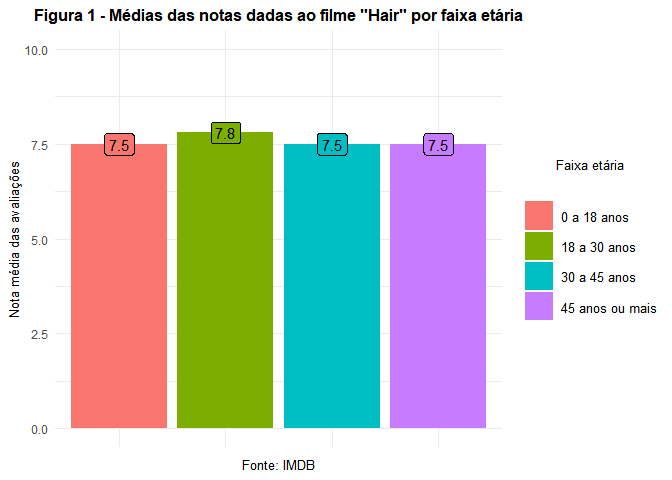

```r
# Carregando os pacotes que irei utilizar para elaborar este gráfico:

library(ggplot2)

# Selecionando os valores das variáveis correspondentes às notas médias por
# faixa etária

notas <- imdb_completa %>%
  left_join(imdb_avaliacoes, by = "id_filme", copy = TRUE) %>%
  filter(str_detect(titulo, pattern = "Hair$")) %>%
  select(
    nota_media_idade_0_18, nota_media_idade_18_30,
    nota_media_idade_30_45, nota_media_idade_45_mais
  ) %>%
  summarise(nota_media = as.numeric(c(nota_media_idade_0_18, nota_media_idade_18_30, nota_media_idade_30_45, nota_media_idade_45_mais))) %>%
  rowid_to_column()

# Elaborando gráfico sobre as notas médias das avaliações do filme "Hair" por
# faixa etária

faixa_etaria <- list((1:4), c(
  "0 a 18 anos", "18 a 30 anos", "30 a 45 anos",
  "45 anos ou mais"
))
names(faixa_etaria) <- c("rowid", "faixa_etaria")

faixa_etaria <- as.data.frame(faixa_etaria)

# Gráfico das avaliações por idade

grafico_avaliacoes_idade <- notas %>%
  left_join(faixa_etaria, by = "rowid", copy = TRUE) %>%
  select(nota_media, faixa_etaria) %>%
  ggplot(aes(x = faixa_etaria, y = nota_media, fill = faixa_etaria)) +
  geom_col(stat = "identity", show.legend = TRUE) +
  geom_label(aes(label = nota_media), show.legend = FALSE) +
  scale_fill_discrete() +
  ylim(0, 10) +
  labs(
    title = "Figura 1 - Médias das notas dadas ao filme \"Hair\" por faixa etária",
    y = "Nota média das avaliações",
    fill = "Faixa etária",
    caption = "Fonte: IMDB"
  ) +
  theme_minimal() +
  theme(
    strip.text = element_text(size = 12),
    axis.text.x = element_blank(),
    axis.title.x = element_blank(),
    axis.line.x = element_blank(),
    axis.title.y = element_text(size = 10),
    strip.text.y = element_text(angle = 0),
    plot.title = element_text(size = 12, face = "bold", hjust = 0.5),
    legend.title = element_text(hjust = 0.5, size = 10),
    legend.text = element_text(size = 10),
    legend.key.size = unit(0.8, "cm"),
    legend.key.height = unit(0.8, "cm"),
    legend.key.width = unit(0.8, "cm"),
    legend.spacing.y = unit(0.8, "cm"),
    plot.caption = element_text(hjust = 0.5, size = 10)
  )
grafico_avaliacoes_idade
```